# Simple example of PCA and MDS

First let look the two first PCs as well as the admixture proportions

```
options(repr.plot.width=12, repr.plot.height=12)

layout(matrix(c(1,1,2,3),nrow=2,by=T),height=c(2,4),width=2:1)
#read in code to plot admixture proportions ( plotAdmix function)
source("https://raw.githubusercontent.com/GenisGE/evalAdmix/master/visFuns.R")


# Read in inferred admixture proportions
q <- read.table("~/kenya2024/admixture/multiRunK7/blue_wildebeest_noLD.7.Q_4")

#read in the population labels (first column of fam file)
tab <- table(pop <- read.table("~/kenya2024/admixture/blue_wildebeest_noLD.fam")[,1])

#make the plot.
plotAdmix(q,pop=pop,rotatelab=15,padj=0.15,cex.lab=1.4,col=c(3,5,8,4,2,6,7))


pca <- read.table("~/kenya2024/admixture/blue_wildebeest_thin.eigvecs")

#layout(matrix(1:2,nrow=1),w=c(4,2))
plot(pca[,1:2],col=as.integer(as.factor(pop))+1,ylab=paste("PC",1),xlab=paste("PC",2),cex.lab=1.5,cex=2,lwd=8)
plot.new()
legend("top",legend=names(tab),bty="n",xpd=T,cex=2,text.col=1:length(tab)+1,text.font=2)
```

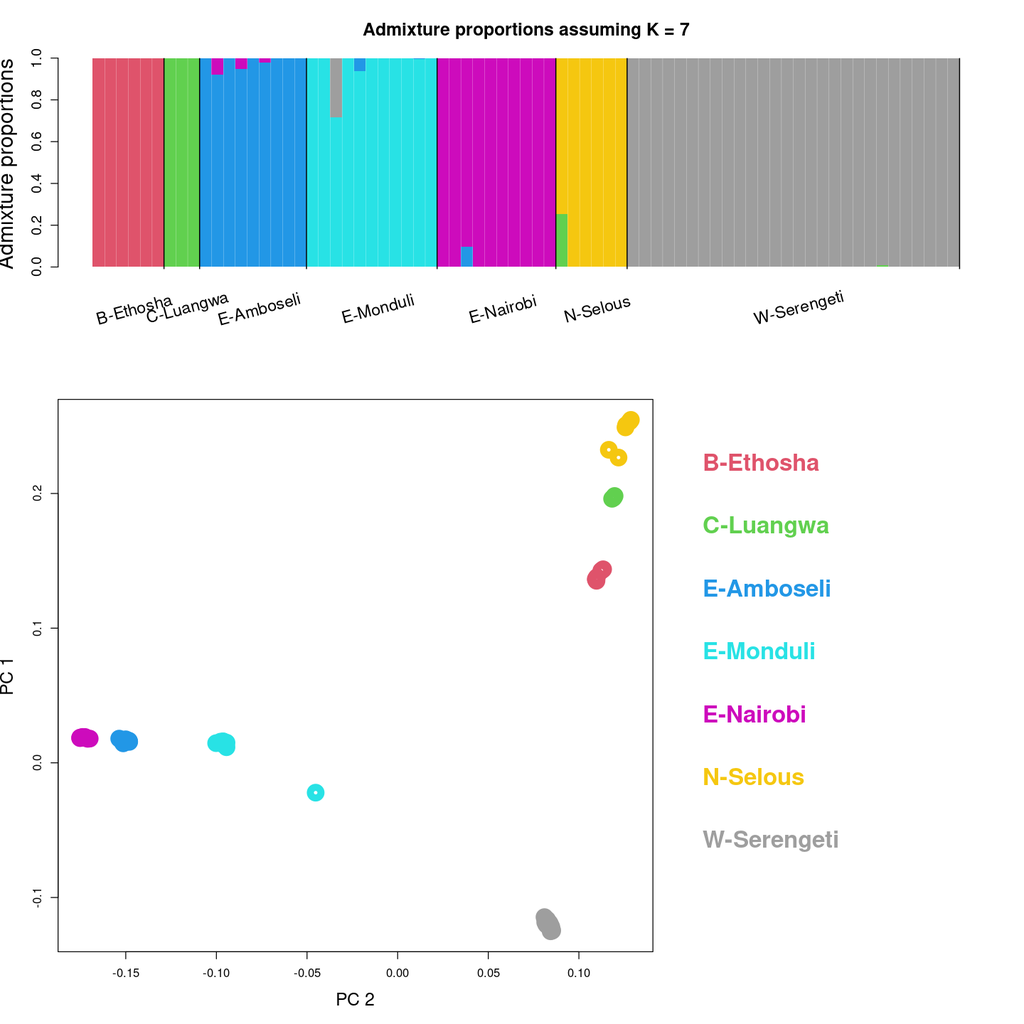

- What information do you get from the PCA that you don't get from the ADMIXTURE results?
- Can you identify the admixed individuals?

Lets see what the other PCs show.

```
options(repr.plot.width=12, repr.plot.height=16)

par(mfrow=c(3,2))
for(pc in 0:4)
    plot(pca[,pc*2+1:2],col=as.integer(as.factor(pop))+1,ylab=paste("PC",pc*2+2),xlab=paste("PC",pc*2+1),cex.lab=1.5,cex=2,lwd=8)
```

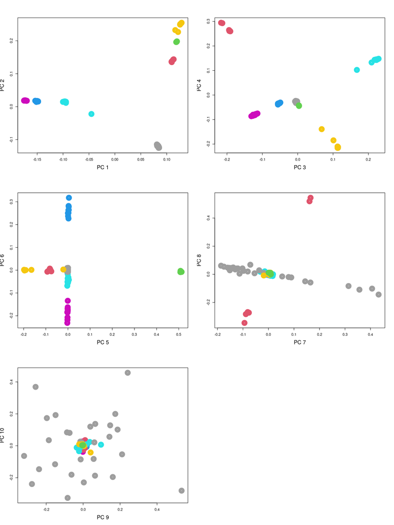

- How many PCs are used to separate the populations?
- What do you think is captured on PC 7 and 8?
- What do you think is captures on PC 9 and 10?

## Bonus exercise if there is time

Lets try to run the PCA after pruning LD (linkage disequillibrium) from the data. The noLD data was created in the admixture exercise. Run the PCA

[output not shown]

[output not shown]

We can start by comparing the eigenvalue. These are proportional to the variance explained so that higher values means that the corresponding PC captures more information about the data.

[output not shown]

- which data set captures the most information about the population structure from the first top PCs?

Lets plot the PCs from the two data sets

[output not shown]

- Which of the PCs from prevous analysis capture LD and not population structure?
- Do you think it is better to perform PCA with out without LD?

## Identity by state tree

As a last minute addition we can also make a neighbour joining tree mentioned in the lecture by first computing identity-by-state distances between individuals which a just the proportion of sites between two individuals where they are different. We can then load these distances into R and produce a NJ tree with the package APE.

```
# get IBS distances with plink
plink --allow-extra-chr --bfile blue_wildebeest_thin --distance square 1-ibs --chr-set 29
```

[output not shown]